# Slight Webb Data inspection

#### Date: 26Jan2024

#### Author: Jrose

Here I am loading in an anndata object I created from the downloaded seurat object from the Slight-Webb study.

This study included scRNA + CITEseq of 29 individuals (SLE and HC) of either white or black ancestry

I'm not sure what cell types are included so hoping to find out here.

```python
import scanpy as sc
import os

data_dir="../data/SlightWebb"
file="SlightWebb_AnnData.h5ad"

adata_path = os.path.join(data_dir, file)

adata = sc.read(adata_path)
```

```python
adata
```

```
AnnData object with n_obs × n_vars = 88053 × 27254
    obs: 'orig.ident', 'nCount_RNA', 'nFeature_RNA', 'nCount_CITE', 'nFeature_CITE', 'nCount_HTO', 'nFeature_HTO', 'HTO_maxID', 'HTO_secondID', 'HTO_margin', 'HTO_classification', 'HTO_classification.global', 'hash.ID', 'deMULTIplex.calls', 'deMULTIplex.calls.rescued', 'final.HTO.ID', 'run', 'subjec…
    var: 'name'
    obsm: 'X_harmony', 'X_harmony_cite', 'X_pca', 'X_pca_cite', 'X_umap_wnn'
```

```python
adata.obs['coarse_cell_type'].value_counts()
```

```
coarse_cell_type
Monocytes       42785
B cells         21698
NK cells        15088
T cells          5187
pDCs             1508
Plasmablasts      876
Progenitors       563
cDCs              348
Name: count, dtype: int64
```

```python
adata.obs['classification'].value_counts()
```

```
classification
Control      31082
SLE INACT    29838
SLE ACT      27133
Name: count, dtype: int64
```

```python
adata.obs['clusters_annotated'].value_counts()
```

```
clusters_annotated
Classical monos           18104
Naive B cells             15417
NK cells                  15088
Non-classical monos        4776
S100A8/A9hi monos          4646
Intermediate monos         3334
Memory B cells             3279
LYZhi, IFI6hi monos        3150
CD4+ T cells               2606
CXCL8hi monos              2255
CCL3hi monos               2025
CD14Med, CD16Lo monos      1895
CD8+ cytotoxic T cells     1620
pDCs                       1508
GC B cells                 1328
ISGhi monos                1186
Transitional B cells       1062
CD8+ T cells                961
CD85jhi, CD94hi monos       884
Plasmablasts                876
ABC/DN B cells              612
Progenitors                 563
CD56hi monos                530
CD1c+ cDC2s                 189
CLEC9A+ cDC1s               159
Name: count, dtype: int64
```

It seems like this is PBMC data, with other cell types but a large number of B cells which is what we want

### Select out only B cells & Plasmablasts

```python
Bmask = (adata.obs['coarse_cell_type']=='B cells') | (adata.obs['coarse_cell_type']=='Plasmablasts')

B_adata = adata[Bmask, :]
B_adata
```

```
View of AnnData object with n_obs × n_vars = 22574 × 27254
    obs: 'orig.ident', 'nCount_RNA', 'nFeature_RNA', 'nCount_CITE', 'nFeature_CITE', 'nCount_HTO', 'nFeature_HTO', 'HTO_maxID', 'HTO_secondID', 'HTO_margin', 'HTO_classification', 'HTO_classification.global', 'hash.ID', 'deMULTIplex.calls', 'deMULTIplex.calls.rescued', 'final.HTO.ID', 'run', 'subjec…
    var: 'name'
    obsm: 'X_harmony', 'X_harmony_cite', 'X_pca', 'X_pca_cite', 'X_umap_wnn'
```

```python
B_adata.obs['fine_cell_type'].value_counts()
```

```
fine_cell_type
Naive B cells           16745
Memory B cells           3279
Transitional B cells     1062
Plasmablasts              876
ABCs                      612
Name: count, dtype: int64
```

```python
B_adata.obs['clusters_annotated'].value_counts()
```

```
clusters_annotated
Naive B cells           15417
Memory B cells           3279
GC B cells               1328
Transitional B cells     1062
Plasmablasts              876
ABC/DN B cells            612
Name: count, dtype: int64
```

Okay what about ancestry groups

```python
B_adata.obs['ancestry'].value_counts()
```

```
ancestry
EA    12701
AA     9873
Name: count, dtype: int64
```

```python
B_adata.obs['run'].value_counts()
```

```
run
s3b    3882
s1a    3257
s1b    2895
s4a    2349
s4b    2191
s2b    2159
s5a    2080
s2a    1950
s5b    1523
s3a     288
Name: count, dtype: int64
```

### Exploration

Now let's do a little exploring to see what sort of gene expression these B cells have without having to recalculate much in terms of variable genes, umap, pca, etc

```python
B_adata.layers["counts"] = B_adata.X.copy()
sc.pp.normalize_total(B_adata, target_sum=1e4)
sc.pp.log1p(B_adata)
```

```python
#sc.pp.highly_variable_genes(
#    B_adata,
#    n_top_genes=2000,
#    subset=True,
#    layer="counts",
#    flavor="seurat_v3",
#    #batch_key="run",
#    #For some reason including batch/run threw an error?
#)
```

```python
B_adata
```

```
AnnData object with n_obs × n_vars = 22574 × 27254
    obs: 'orig.ident', 'nCount_RNA', 'nFeature_RNA', 'nCount_CITE', 'nFeature_CITE', 'nCount_HTO', 'nFeature_HTO', 'HTO_maxID', 'HTO_secondID', 'HTO_margin', 'HTO_classification', 'HTO_classification.global', 'hash.ID', 'deMULTIplex.calls', 'deMULTIplex.calls.rescued', 'final.HTO.ID', 'run', 'subjec…
    var: 'name'
    uns: 'log1p'
    obsm: 'X_harmony', 'X_harmony_cite', 'X_pca', 'X_pca_cite', 'X_umap_wnn'
    layers: 'counts'
```

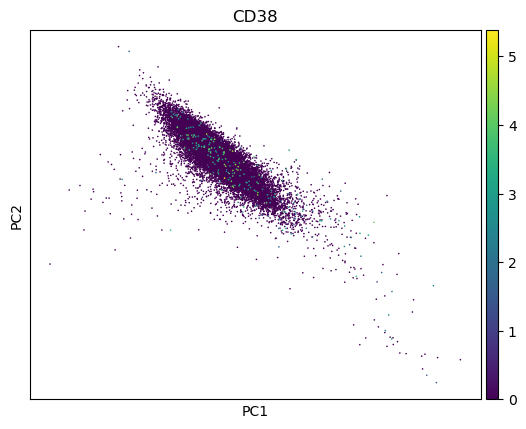

```python
sc.pl.pca(B_adata, color='CD38')
```

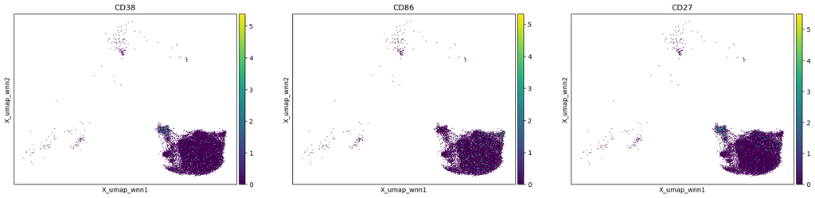

```python
sc.pl.embedding(B_adata, basis='X_umap_wnn',color=['CD38', 'CD86', 'CD27'])
```

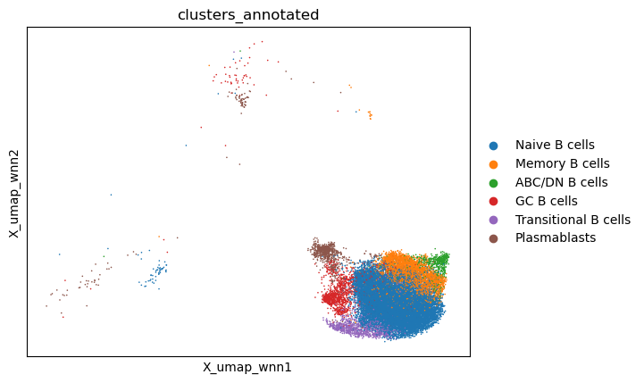

```python
sc.pl.embedding(B_adata, basis='X_umap_wnn', color=['clusters_annotated'])
```

Hmmm umaps, embeddings, and pca seem to be calculated from the larger PBMC dataset. Need to recalculate for the B cell subset

Remarkably a small part of the overall UMAP seems to be VERY similar to the original publication umap in figure 4!

#### Can I do simpler plots (violin, heatmap, etc) for annotated clusters?

[output not shown]

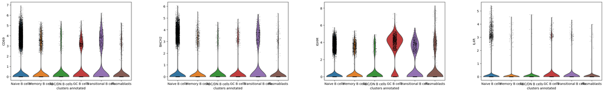

```python
sc.pl.violin(B_adata, ['CD69','BACH2','IGHM','IL4R'], groupby='clusters_annotated')
```

```python
marker_genes_dict = {
    'Naive': ['CD79A', 'PAX5', 'BACH2'],
    'Memory': ['CD27', 'CD70'],
    'PB':['IGHM','IGHD', 'IGKC','JCHAIN','IGLC2'],
    'Active': ['CD86', 'IRF4', 'IRF8'],
    'GC': ['BCL6', 'IL21R', 'IL4R','CXCR5'],
    'DN2': ['TBX21', 'ATF3', 'STAT4']
}
```

```
WARNING: dendrogram data not found (using key=dendrogram_clusters_annotated). Running `sc.tl.dendrogram` with default parameters. For fine tuning it is recommended to run `sc.tl.dendrogram` independently.
WARNING: Groups are not reordered because the `groupby` categories and the `var_group_labels` are different.
categories: Naive B cells, Memory B cells, ABC/DN B cells, etc.
var_group_labels: Naive, Memory, PB, etc.
```

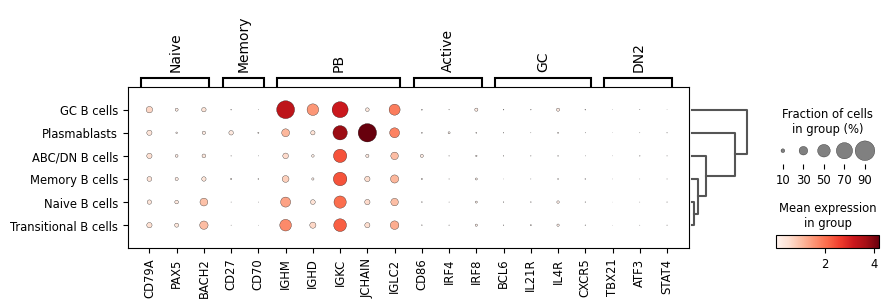

```python
sc.pl.dotplot(B_adata, marker_genes_dict, 'clusters_annotated', dendrogram=True)
```

Funny to see how many of the "marker" genes of certain cell types don't show up in single-cell data...just not deep enough sequencing

```
WARNING: dendrogram data not found (using key=dendrogram_classification). Running `sc.tl.dendrogram` with default parameters. For fine tuning it is recommended to run `sc.tl.dendrogram` independently.
WARNING: Groups are not reordered because the `groupby` categories and the `var_group_labels` are different.
categories: Control, SLE INACT, SLE ACT
var_group_labels: Naive, Memory, PB, etc.
```

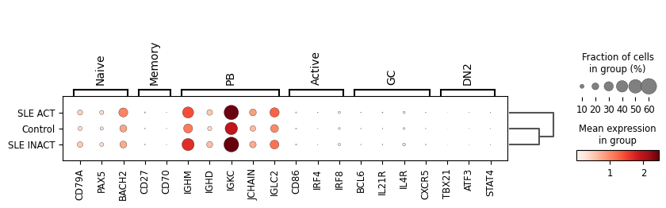

```python
sc.pl.dotplot(B_adata, marker_genes_dict, 'classification', dendrogram=True)
```

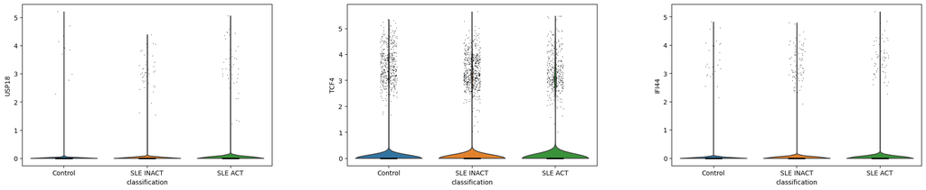

```python
sc.pl.violin(B_adata, ['USP18','TCF4','IFI44'], groupby='classification', use_raw=False)
```

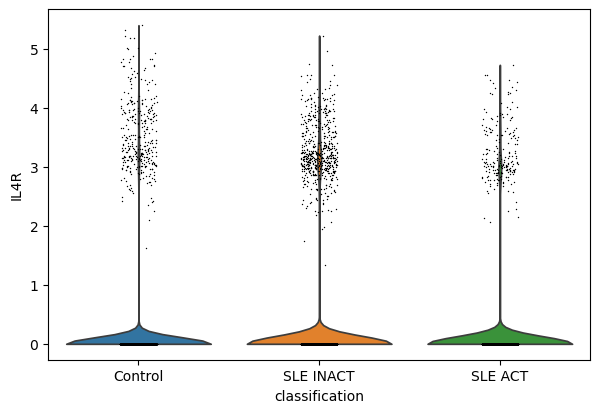

```python
sc.pl.violin(B_adata, ['IL4R'], groupby='classification', use_raw=False)
```

```
WARNING: Groups are not reordered because the `groupby` categories and the `var_group_labels` are different.
categories: Control, SLE INACT, SLE ACT
var_group_labels: Down, IFN, Inact
```

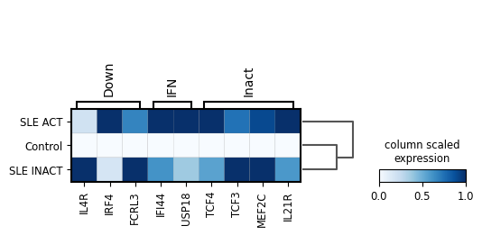

```python
SLE_marker_genes_dict = {
    'Down': ['IL4R', 'IRF4','FCRL3'],
    'IFN': ['IFI44', 'USP18'],
    'Inact': ['TCF4','TCF3','MEF2C','IL21R']
}

sc.pl.matrixplot(B_adata, SLE_marker_genes_dict, 'classification', dendrogram=True, cmap='Blues', standard_scale='var', colorbar_title='column scaled\nexpression')
```

```
WARNING: Groups are not reordered because the `groupby` categories and the `var_group_labels` are different.
categories: Naive B cells, Memory B cells, ABC/DN B cells, etc.
var_group_labels: Naive, Memory, PB, etc.
```

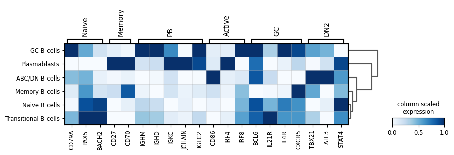

```python
sc.pl.matrixplot(B_adata, marker_genes_dict, 'clusters_annotated', dendrogram=True, cmap='Blues', standard_scale='var', colorbar_title='column scaled\nexpression')
```

```python
B_adata_naive = B_adata[B_adata.obs['clusters_annotated']=='Naive B cells'].copy()
```

```
WARNING: Groups are not reordered because the `groupby` categories and the `var_group_labels` are different.
categories: Control, SLE INACT, SLE ACT
var_group_labels: Down, IFN, Inact
```

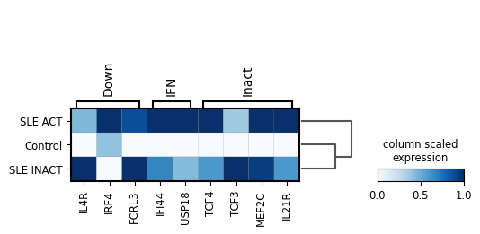

```python
sc.pl.matrixplot(B_adata_naive, SLE_marker_genes_dict, 'classification', dendrogram=True, cmap='Blues', standard_scale='var', colorbar_title='column scaled\nexpression')
```

It would appear that most of these cell annotations are correct according to traditional cell markers

The next step would be to try and model this using integration methods (scvi). To enable this let's save the B cell specific object

### Save B Cell anndata object

```python
B_adata
```

```
AnnData object with n_obs × n_vars = 22574 × 27254
    obs: 'orig.ident', 'nCount_RNA', 'nFeature_RNA', 'nCount_CITE', 'nFeature_CITE', 'nCount_HTO', 'nFeature_HTO', 'HTO_maxID', 'HTO_secondID', 'HTO_margin', 'HTO_classification', 'HTO_classification.global', 'hash.ID', 'deMULTIplex.calls', 'deMULTIplex.calls.rescued', 'final.HTO.ID', 'run', 'subjec…
    var: 'name'
    uns: 'log1p'
    obsm: 'X_harmony', 'X_harmony_cite', 'X_pca', 'X_pca_cite', 'X_umap_wnn'
    layers: 'counts'
```

```python
data_dir="../data/SlightWebb"
Bfile="SlightWebb_Bcell_AnnData.h5ad"

Badata_path = os.path.join(data_dir, Bfile)

B_adata.write(Badata_path)
```

#### Let's recalculate the PCA and umap for just B cells

```python
B_adata.raw = B_adata

B_adata = B_adata[:, B_adata.var.highly_variable]

sc.pp.regress_out(B_adata, ['nCount_RNA'])
sc.pp.scale(B_adata, max_value=10)
sc.tl.pca(B_adata, svd_solver='arpack')
B_adata
```

[output not shown]

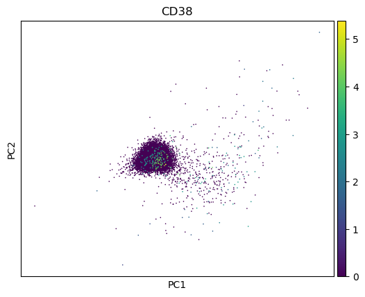

```python
sc.pl.pca(B_adata, color='CD38')
```

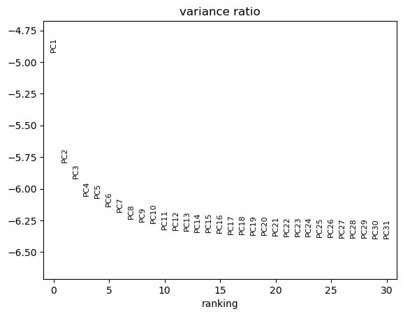

```python
sc.pl.pca_variance_ratio(B_adata, log=True)
```

```python
sc.pp.neighbors(B_adata, n_neighbors=10, n_pcs=25)
#sc.tl.paga(B_adata)
#sc.pl.paga(B_adata, plot=False)  # remove `plot=False` if you want to see the coarse-grained graph
#sc.tl.umap(B_adata, init_pos='paga')
```

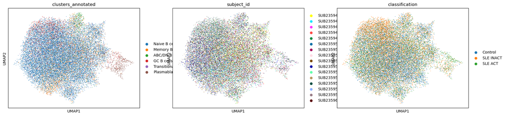

```python
sc.tl.umap(B_adata)
sc.pl.umap(B_adata, color=['clusters_annotated', 'subject_id', 'classification'])
```

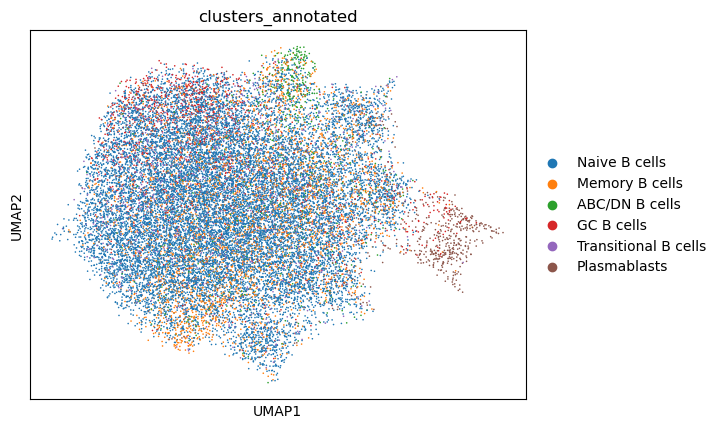

```python
sc.pl.umap(B_adata, color=['clusters_annotated'])
```